# A tutorial to select participants and create two balanced groups using propensity scores

### Propensity scores distribution

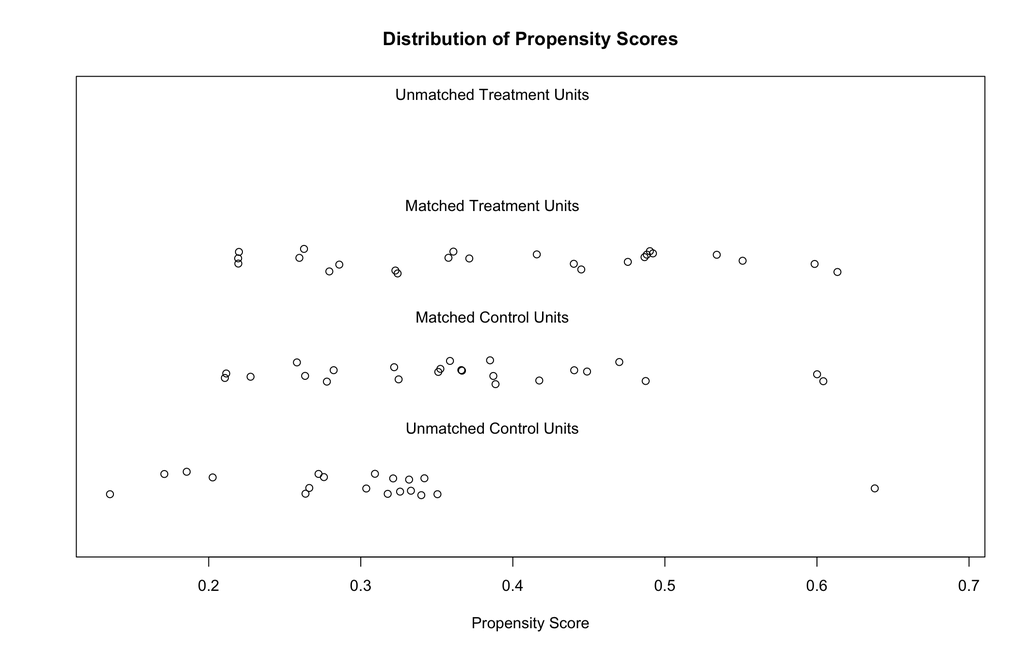

```r
# nearest neighbor
plot(m_near_n67, type = "jitter", interactive = F)
```

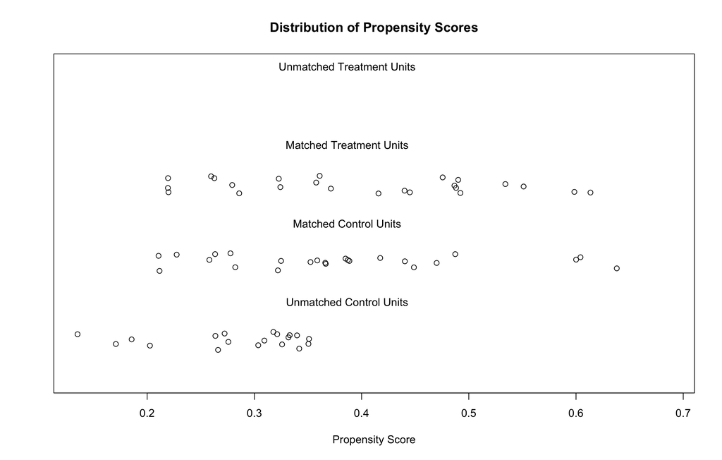

```r
# optimal matching
plot(m_opt_n67, type = "jitter", interactive = F)
```

### Calculate standardized mean differences and variance ratios

```r
# nearest neighbor
# a) create vectors with data in asd and td group
near_asd_n67 <- m_near_n67_df %>%
  filter(group == "ASD")

near_td_n67 <- m_near_n67_df %>%
  filter(group == "TD")

# b) standardized mean difference of propensity score
(mean(near_asd_n67$distance) - mean(near_td_n67$distance)) / sd(near_asd_n67$distance)
```

```
## [1] 0.2417592
```

```r
# c) variance ratio
(sd(near_asd_n67$distance)^2) / (sd(near_td_n67$distance)^2)
```

```
## [1] 1.324467
```

```r
# optimal matching
# a) create vectors with data in asd and td group
opt_asd_n67 <- m_opt_n67_df %>%
  filter(group == "ASD")

opt_td_n67 <- m_opt_n67_df %>%
  filter(group == "TD")

# b) standardized mean difference of propensity score
(mean(opt_asd_n67$distance) - mean(opt_td_n67$distance)) / sd(opt_asd_n67$distance)
```

```
## [1] 0.1443307
```

```r
# c) variance ratio
(sd(opt_asd_n67$distance)^2) / (sd(opt_td_n67$distance)^2)
```

```
## [1] 1.04522
```

### Get list of matched participants and all covariates to report in study

As seen in the table and figure below, our final revised sample with the optimal matching method resulted in two successfully balanced groups according to criteria listed above on our covariates of interest, age and IQ. We next examined other variables not included in our propensity scores, but may be related to group diagnosis and/or performance on outcome measures.

The matched groups met the cut-off for *p* values > .5 on the ratio of English- to French-speaking children. On measures of sex, parental education level, and CELF-4 Word Association, groups were not significantly different (*p*’s between .136 and .461), but these values did not meet recommended matching cutoffs of *p* > .5.

As expected prior to selecting participants, groups were significantly different in their distribution on language measures of Recalling Sentences and Word Classes. Additionally, as expected due to diagnoses, groups were significantly different on social skills measures of the SCQ and VABS-II Socialization domain.

```r
# get list of participants
matchit_list <- m_opt_n67_df %>%
  select(participant)

# create df with participants in matched groups
df_matchit <- df2 %>%
  right_join(matchit_list, by = "participant") %>%
  select(-c(keep, celf4_WC_rec_scaled, celf4_WC_exp_scaled)) %>%
  mutate(group = factor(group), language = factor(language),
         sex = factor(sex), parental_ed = factor(parental_ed),
         block1 = factor(block1))

# check number of rows of participants
nrow(df_matchit)
```

```
## [1] 48
```

### Calculate inferential statistics

```r
# remove participant column to run compareGroups
df_matchit2 <- df_matchit %>%
  select(-participant)

# compareGroups uses Fisher's exact test as a default when cell values < 5
compare_group <- compareGroups(group ~ . , data = df_matchit2)
compare_group_tbl <- createTable(compare_group, digits = 2, type = 1, show.n = TRUE)
print(compare_group_tbl, header.labels = c(p.overall = "p-value"))
```

```
##
## --------Summary descriptives table by 'group'---------
##
## ______________________________________________________________
##                            ASD             TD       p-value N
##                            N=24           N=24
## ¯¯¯¯¯¯¯¯¯¯¯¯¯¯¯¯¯¯¯¯¯¯¯¯¯¯¯¯¯¯¯¯¯¯¯¯¯¯¯¯¯¯¯¯¯¯¯¯¯¯¯¯¯¯¯¯¯¯¯¯¯¯
## age_yrs                8.83 (1.26)    8.70 (1.12)    0.713  48
## language:                                            1.000  48
##     English               45.83%         41.67%
##     French                54.17%         58.33%
## sex:                                                 0.461  48
##     F                     12.50%         25.00%
##     M                     87.50%         75.00%
## block1:                                              1.000  48
##     order1                50.00%         54.17%
##     order2                50.00%         45.83%
## parental_ed:                                         0.136  48
##     0                     50.00%         25.00%
##     1                     50.00%         75.00%
## leiter_composite      108.29 (12.65) 109.50 (13.24)  0.748  48
## celf4_RS_scaled        8.08 (4.16)    11.17 (2.18)   0.003  48
## celf4_WC_total_scaled  9.74 (3.74)    12.08 (3.06)   0.024  47
## celf4_WA_total        29.92 (15.01)  33.29 (11.17)   0.382  48
## scq_total              20.88 (5.83)   4.42 (2.62)   <0.001  48
## social_standScore     76.83 (11.64)  110.00 (11.88) <0.001  48
## ¯¯¯¯¯¯¯¯¯¯¯¯¯¯¯¯¯¯¯¯¯¯¯¯¯¯¯¯¯¯¯¯¯¯¯¯¯¯¯¯¯¯¯¯¯¯¯¯¯¯¯¯¯¯¯¯¯¯¯¯¯¯
```

### Calculate Cohen’s *d* and variance ratios

```r
# create separate vectors for groups
asd <- df_matchit %>%
  filter(group == "ASD")

td <- df_matchit %>%
  filter(group == "TD")

# age_yrs - cohen's d and variance ratios
age_yrs_es <- mes(mean(asd$age_yrs), mean(td$age_yrs),
                  sd(asd$age_yrs), sd(td$age_yrs),
                  nrow(asd), nrow(td), verbose = F)
age_yrs <- age_yrs_es[, 4]
age_yrs_es_ci <- age_yrs_es[, 6:7]
age_yrs_es_vr <- (sd(asd$age_yrs)^2)/(sd(td$age_yrs)^2)


# celf4_RS_scaled - cohen's d and variance ratios
celf4_rs_es <- mes(mean(asd$celf4_RS_scaled), mean(td$celf4_RS_scaled),
                   sd(asd$celf4_RS_scaled), sd(td$celf4_RS_scaled),
                   nrow(asd), nrow(td), verbose = F)
celf4_rs <- celf4_rs_es[, 4]
celf4_rs_es_ci <- celf4_rs_es[, 6:7]
celf4_rs_es_vr <- (sd(asd$celf4_RS_scaled)^2)/(sd(td$celf4_RS_scaled)^2)


# celf4_WC_total_scaled - cohen's d and variance ratios
# removing child with no score for WC
asd2 <- asd %>%
  filter(participant != 420)

celf4_wc_es <- mes(mean(asd2$celf4_WC_total_scaled), mean(td$celf4_WC_total_scaled),
                   sd(asd2$celf4_WC_total_scaled), sd(td$celf4_WC_total_scaled),
                   nrow(asd2), nrow(td), verbose = F)
celf4_wc <- celf4_wc_es[, 4]
celf4_wc_es_ci <- celf4_wc_es[, 6:7]
celf4_wc_es_vr <- (sd(asd2$celf4_WC_total_scaled)^2)/(sd(td$celf4_WC_total_scaled)^2)


# celf4_WA_total - cohen's d and variance ratios
celf4_wa_es <- mes(mean(asd$celf4_WA_total), mean(td$celf4_WA_total),
                   sd(asd$celf4_WA_total), sd(td$celf4_WA_total),
                   nrow(asd), nrow(td), verbose = F)
celf4_wa <- celf4_wa_es[, 4]
celf4_wa_es_ci <- celf4_wa_es[, 6:7]
celf4_wa_es_vr <- (sd(asd$celf4_WA_total)^2)/(sd(td$celf4_WA_total)^2)


# leiter_composite - cohen's d and variance ratios
leiter_es <- mes(mean(asd$leiter_composite), mean(td$leiter_composite),
                 sd(asd$leiter_composite), sd(td$leiter_composite),
                 nrow(asd), nrow(td), verbose = F)
leiter <- leiter_es[, 4]
leiter_es_ci <- leiter_es[, 6:7]
leiter_es_vr <- (sd(asd$leiter_composite)^2)/(sd(td$leiter_composite)^2)


# scq_total - cohen's d and variance ratios
scq_es <- mes(mean(asd$scq_total), mean(td$scq_total),
              sd(asd$scq_total), sd(td$scq_total),
              nrow(asd), nrow(td), verbose = F)
scq <- scq_es[, 4]
scq_es_ci <- scq_es[, 6:7]
scq_es_vr <- (sd(asd$scq_total)^2)/(sd(td$scq_total)^2)


# social_standScore - cohen's d and variance ratios
vineland_es <- mes(mean(asd$social_standScore), mean(td$social_standScore),
                   sd(asd$social_standScore), sd(td$social_standScore),
                   nrow(asd), nrow(td), verbose = F)
vineland <- vineland_es[, 4]
vineland_es_ci <- vineland_es[, 6:7]
vineland_es_vr <- (sd(asd$social_standScore)^2)/(sd(td$social_standScore)^2)


es_d <- rbind(age_yrs, celf4_rs, celf4_wc, celf4_wa, leiter, scq, vineland)
es_ci <- rbind(age_yrs_es_ci, celf4_rs_es_ci, celf4_wc_es_ci, celf4_wa_es_ci, leiter_es_ci, scq_es_ci, vineland_es_ci)
es_vr <- rbind(age_yrs_es_vr, celf4_rs_es_vr, celf4_wc_es_vr, celf4_wa_es_vr, leiter_es_vr, scq_es_vr, vineland_es_vr)

effect_sizes <- cbind(es_d, es_ci, es_vr)
effect_sizes %>%
  rename( d = 1, d_CI_lower_bound = 2, d_CI_upper_bound = 3, vr = 4)
```

```
##              d d_CI_lower_bound d_CI_upper_bound        vr
## age_yrs   0.11            -0.46             0.67 1.2742083
## celf4_rs -0.93            -1.52            -0.33 3.6387195
## celf4_wc -0.69            -1.28            -0.10 1.4939979
## celf4_wa -0.26            -0.82             0.31 1.8049142
## leiter   -0.09            -0.66             0.47 0.9119877
## scq       3.64             2.72             4.57 4.9458817
## vineland -2.82            -3.62            -2.02 0.9591544
```

### Create violin plots to examine continuous variables

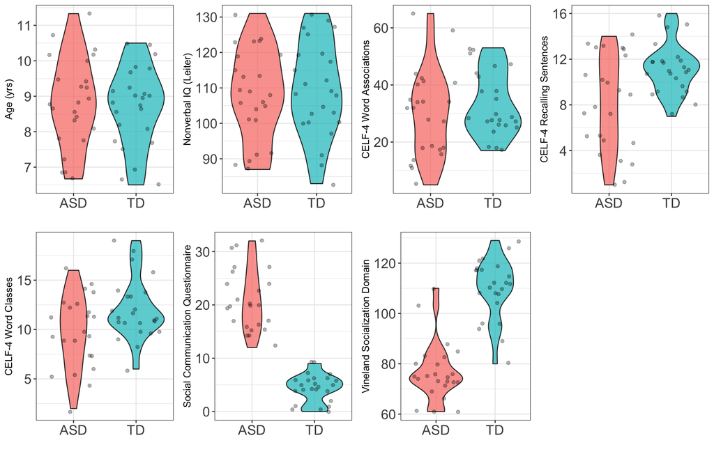

Points represent observations per participant. For age and nonverbal IQ, matching was achieved according to criteria of *p* > .5, Cohen’s *d* close to 0, and variance ratios close to 1. CELF-4 Word Associations did not meet criteria of *p* > .5, but between groups the distribution on this variable appears similar between groups. Groups are significantly different on other language measures of CELF-4 Recalling Sentences and Word Classes, as well as the Social Communication Questionnaire (SCQ) and the Vineland Socialization Domain.

```r
# create violin plots
p1 <- ggplot(df_matchit, aes(group, age_yrs, fill = group)) +
  geom_violin(alpha = .7) +
  geom_jitter(alpha = .3) +
  theme(legend.position = "none", axis.text=element_text(size=15)) +
  labs(y = "Age (yrs)", x = "")
p2 <- ggplot(df_matchit, aes(group, leiter_composite, fill = group)) +
  geom_violin(alpha = .7) +
  geom_jitter(alpha = .3) +
  theme(legend.position = "none", axis.text=element_text(size=15)) +
  labs(y = "Nonverbal IQ (Leiter)", x = "")
p3 <- ggplot(df_matchit, aes(group, celf4_WA_total, fill = group)) +
  geom_violin(alpha = .7) +
  geom_jitter(alpha = .3) +
  theme(legend.position = "none", axis.text=element_text(size=15)) +
  labs(y = "CELF-4 Word Associations", x = "")

p4 <- ggplot(df_matchit, aes(group, celf4_RS_scaled, fill = group)) +
  geom_violin(alpha = .7) +
  geom_jitter(alpha = .3) +
  theme(legend.position = "none", axis.text=element_text(size=15)) +
  labs(y = "CELF-4 Recalling Sentences", x = "")
p5 <- ggplot(df_matchit, aes(group, celf4_WC_total_scaled, fill = group)) +
  geom_violin(alpha = .7) +
  geom_jitter(alpha = .3) +
  theme(legend.position = "none", axis.text=element_text(size=15)) +
  labs(y = "CELF-4 Word Classes", x = "")
p6 <- ggplot(df_matchit, aes(group, scq_total, fill = group)) +
  geom_violin(alpha = .7) +
  geom_jitter(alpha = .3) +
  theme(legend.position = "none", axis.text=element_text(size=15)) +
  labs(y = "Social Communication Questionnaire", x = "")
p7 <- ggplot(df_matchit, aes(group, social_standScore, fill = group)) +
  geom_violin(alpha = .7) +
  geom_jitter(alpha = .3) +
  theme(legend.position = "none", axis.text=element_text(size=15)) +
  labs(y = "Vineland Socialization Domain", x = "")

# print violin plots
grid.arrange(p1, p2, p3, p4, p5, p6, p7, nrow = 2)
```

# Examine matched groups when including age, nonverbal IQ, and language (Recalling Sentences)

To examine the consequences of matching on age, nonverbal IQ and language, we conducted the nearest neighbor and optimal matching methods with all three variables. We chose the Recalling Sentences subtest to represent our language variable, because on Word Classes one child with ASD was unable to complete the measure and on Word Associations the distribution between groups in the full sample appeared similar (see above matrix).

With either the nearest neighbor or optimal matching method, including all three variables of age, nonverbal IQ and language resulted in different sets of TD children as potential matches for the 25 children with ASD. Matched groups with both matching methods that used three covariates resulted in less well-balanced matches than with just two covariates of age and IQ.

For example, as seen in the figure below, an examination of the distribution of propensity scores with the optimal matching method demonstrated that 8 children with ASD were outside the range of propensity scores relative to the rest of the children with ASD and TD children. The table below describes the propensity scores and each covariate when including age, nonverbal IQ, and CELF-4 Recalling Sentences. Only the variable of age meets the desired cutoff of *p* > .5, and the distribution of CELF-4 Recalling Sentences still appears substantially different between both groups (propensity score Cohen’s *d* > .5, propensity score variance ratios > 3, and *p*s < .5 for two of three variables).

Due to the poor balancing when including all three proposed covariates, this evidence supports balancing on two covariates of age and nonverbal IQ to retain as many children in the sample as possible. Additionally, because language abilities of children with ASD were not categorically poorer across all three measures relative to TD children, it is unclear on which language measure to match when intercorrelations between language measures ranged widely across the full sample (*r*s = .28 - .72), within ASD (*r*s = .34 - .84) and within TD children (*r*s = .09 - .47).

Therefore, matching groups on two covariates of age and nonverbal IQ appear to be both theoretically supported based on prior studies and empirically supported by the current evidence with our sample.

### Select covariates

```r
df_ps_n68_3cov <- df2 %>%
  select(participant, group, age_yrs, leiter_composite, celf4_RS_scaled) %>%
  mutate(group.int = ifelse(group == "ASD", 1, 0)) # group must be an integer for MatchIt
```

### Conduct Nearest neighbor algorithm: n = 68 including age, IQ, and language (Recalling Sentences)

```r
# apply matching
m_near_n68_3cov <- matchit(group.int ~ age_yrs + leiter_composite + celf4_RS_scaled,
                     data = df_ps_n68_3cov, method = "nearest")

# obtain list of matched participants
m_near_n68_3cov_df <- match.data(m_near_n68_3cov)
m_near_n68_3cov_df$participant
```

```
##  [1] 302 304 306 307 310 311 312 313 314 315 317 318 319 321 322 323 324 326 330
## [20] 331 332 333 339 341 347 351 401 402 403 404 406 408 410 411 412 414 416 417
## [39] 418 420 421 423 424 425 428 430 431 437 439 445
```

#### Diagnose matching - View propensity scores

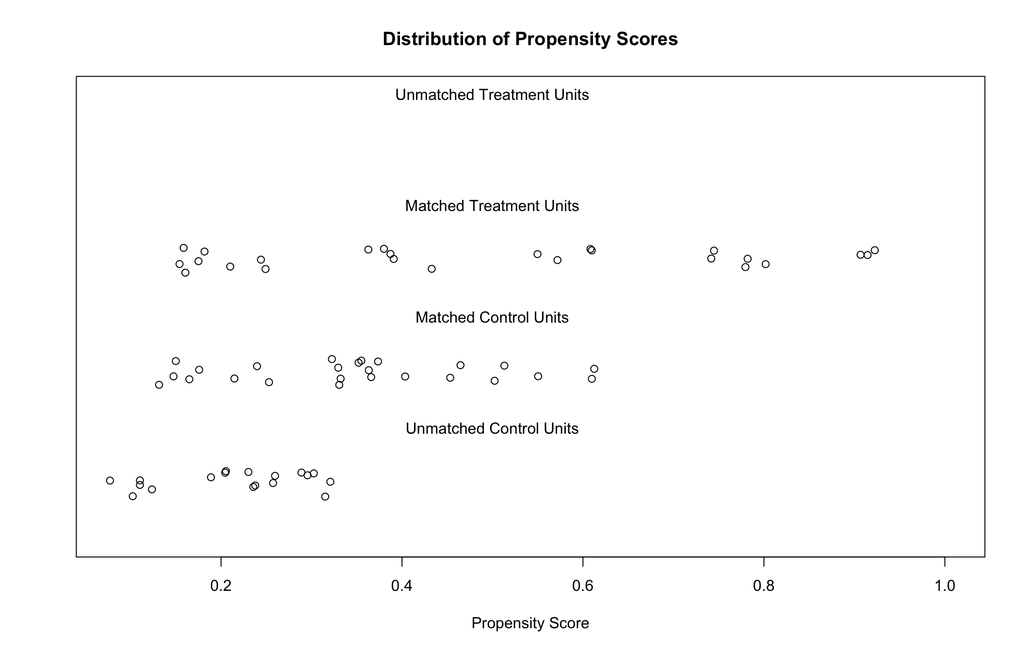

```
## [1] "To identify the units, use first mouse button; to stop, use second."
```

```
## integer(0)
```

```r
# view propensity scores
plot(m_near_n68_3cov, type = "jitter")
```

#### Diagnose matching - Standardized mean difference and Variance ratio

```r
# standardized mean difference
# a) create vectors with data in asd and td group
near_asd_n68_3cov <- m_near_n68_3cov_df %>%
  filter(group == "ASD")

near_td_n68_3cov <- m_near_n68_3cov_df %>%
  filter(group == "TD")

# b) standardized mean difference of propensity score
# (Mtreatment - Mcontrol) / SDtreatment; (Stuart, 2010; Rubin, 2001; Rosenbaum & Rubin, 1985 - The American Statistician)
(mean(near_asd_n68_3cov$distance) - mean(near_td_n68_3cov$distance)) / sd(near_asd_n68_3cov$distance)
```

```
## [1] 0.5498751
```

```r
# variance ratio
(sd(near_asd_n68_3cov$distance)^2) / (sd(near_td_n68_3cov$distance)^2)
```

```
## [1] 3.572499
```

#### Diagnose matching - Descriptive and inferential statistics on age, IQ, and language

```r
# subset only age and IQ
age_IQ_language_3cov <- m_near_n68_3cov_df %>%
  select(group, age_yrs, leiter_composite, celf4_RS_scaled)

# compare groups
age_IQ_language_compare <- compareGroups(group ~ age_yrs + leiter_composite + celf4_RS_scaled, data = age_IQ_language_3cov)
age_IQ_language_compare_tbl <- createTable(age_IQ_language_compare, digits = 2, type = 1, show.n = TRUE)
print(age_IQ_language_compare_tbl, header.labels = c(p.overall = "p-value"))
```

```
##
## --------Summary descriptives table by 'group'---------
##
## _________________________________________________________
##                       ASD             TD       p-value N
##                       N=25           N=25
## ¯¯¯¯¯¯¯¯¯¯¯¯¯¯¯¯¯¯¯¯¯¯¯¯¯¯¯¯¯¯¯¯¯¯¯¯¯¯¯¯¯¯¯¯¯¯¯¯¯¯¯¯¯¯¯¯¯
## age_yrs           8.93 (1.34)    8.73 (1.24)    0.587  50
## leiter_composite 107.16 (13.61) 113.00 (14.89)  0.154  50
## celf4_RS_scaled   7.84 (4.25)    10.00 (2.10)   0.029  50
## ¯¯¯¯¯¯¯¯¯¯¯¯¯¯¯¯¯¯¯¯¯¯¯¯¯¯¯¯¯¯¯¯¯¯¯¯¯¯¯¯¯¯¯¯¯¯¯¯¯¯¯¯¯¯¯¯¯
```

### Conduct Optimal matching algorithm: n = 68 including age, IQ, and language (Recalling Sentences)

```r
# apply matching
m_opt_n68_3cov <- matchit(group.int ~ age_yrs + leiter_composite + celf4_RS_scaled,
                     data = df_ps_n68_3cov, method = "optimal")


# obtain list of matched participants
m_opt_n68_3cov_df <- match.data(m_opt_n68_3cov)
m_opt_n68_3cov_df$participant
```

```
##  [1] 302 304 306 310 311 312 313 314 315 317 318 319 321 322 323 324 326 330 331
## [20] 332 333 339 341 347 349 351 401 402 403 404 406 408 410 411 412 414 416 418
## [39] 420 421 423 424 425 428 430 431 433 437 439 445
```

#### Diagnose matching - View propensity scores

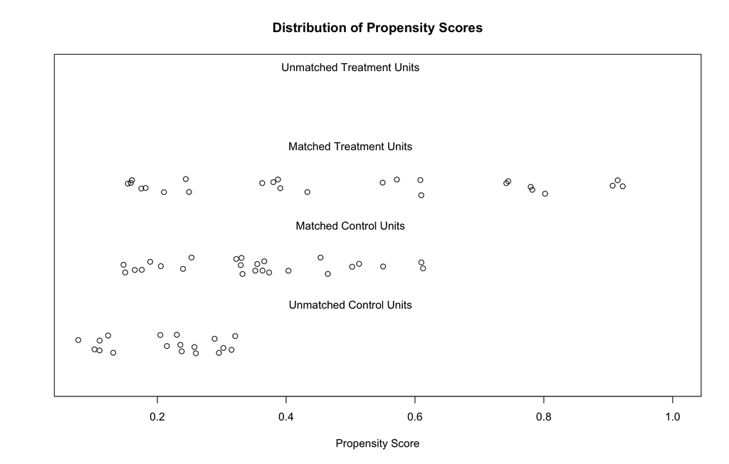

```
## [1] "To identify the units, use first mouse button; to stop, use second."
```

```
## integer(0)
```

```r
# view propensity scores
plot(m_opt_n68_3cov, type = "jitter")
```

#### Diagnose matching - Standardized mean difference and Variance ratio

```r
# standardized mean difference
# a) create vectors with data in asd and td group
opt_asd_n68_3cov <- m_opt_n68_3cov_df %>%
  filter(group == "ASD")

opt_td_n68_3cov <- m_opt_n68_3cov_df %>%
  filter(group == "TD")

# b) standardized mean difference of propensity score
# (Mtreatment - Mcontrol) / SDtreatment; (Stuart, 2010; Rubin, 2001; Rosenbaum & Rubin, 1985 - The American Statistician)
(mean(opt_asd_n68_3cov$distance) - mean(opt_td_n68_3cov$distance)) / sd(opt_asd_n68_3cov$distance)
```

```
## [1] 0.5427627
```

```r
# variance ratio
(sd(opt_asd_n68_3cov$distance)^2) / (sd(opt_td_n68_3cov$distance)^2)
```

```
## [1] 3.717604
```

#### Diagnose matching - Descriptive and inferential statistics on age, IQ, and language

```r
# subset only age and IQ
age_IQ_language_3cov <- m_opt_n68_3cov_df %>%
  select(group, age_yrs, leiter_composite, celf4_RS_scaled)

# compare groups
age_IQ_language_compare <- compareGroups(group ~ age_yrs + leiter_composite + celf4_RS_scaled, data = age_IQ_language_3cov)
age_IQ_language_compare_tbl <- createTable(age_IQ_language_compare, digits = 2, type = 1, show.n = TRUE)
print(age_IQ_language_compare_tbl, header.labels = c(p.overall = "p-value"))
```

```
##
## --------Summary descriptives table by 'group'---------
##
## _________________________________________________________
##                       ASD             TD       p-value N
##                       N=25           N=25
## ¯¯¯¯¯¯¯¯¯¯¯¯¯¯¯¯¯¯¯¯¯¯¯¯¯¯¯¯¯¯¯¯¯¯¯¯¯¯¯¯¯¯¯¯¯¯¯¯¯¯¯¯¯¯¯¯¯
## age_yrs           8.93 (1.34)    8.69 (1.31)    0.520  50
## leiter_composite 107.16 (13.61) 113.80 (15.10)  0.109  50
## celf4_RS_scaled   7.84 (4.25)    9.88 (1.94)    0.036  50
## ¯¯¯¯¯¯¯¯¯¯¯¯¯¯¯¯¯¯¯¯¯¯¯¯¯¯¯¯¯¯¯¯¯¯¯¯¯¯¯¯¯¯¯¯¯¯¯¯¯¯¯¯¯¯¯¯¯
```

### Diagnose matching - Descriptive and inferential statistics on age, IQ, and language - removing 8 ASD outliers

```r
# subset only age and IQ
age_IQ_language_3cov_rm8asd <- m_opt_n68_3cov_df %>%
  filter(distance < .7) %>%
  select(group, age_yrs, leiter_composite, celf4_RS_scaled)


# compare groups
age_IQ_language_compare_rm8asd <- compareGroups(group ~ age_yrs + leiter_composite + celf4_RS_scaled, data = age_IQ_language_3cov_rm8asd)
age_IQ_language_compare_rm8asd_tbl <- createTable(age_IQ_language_compare_rm8asd, digits = 2, type = 1, show.n = TRUE)
print(age_IQ_language_compare_rm8asd_tbl, header.labels = c(p.overall = "p-value"))
```

```
##
## --------Summary descriptives table by 'group'---------
##
## _________________________________________________________
##                       ASD             TD       p-value N
##                       N=17           N=25
## ¯¯¯¯¯¯¯¯¯¯¯¯¯¯¯¯¯¯¯¯¯¯¯¯¯¯¯¯¯¯¯¯¯¯¯¯¯¯¯¯¯¯¯¯¯¯¯¯¯¯¯¯¯¯¯¯¯
## age_yrs           8.65 (1.02)    8.69 (1.31)    0.903  42
## leiter_composite 112.53 (11.62) 113.80 (15.10)  0.760  42
## celf4_RS_scaled   10.12 (2.96)   9.88 (1.94)    0.773  42
## ¯¯¯¯¯¯¯¯¯¯¯¯¯¯¯¯¯¯¯¯¯¯¯¯¯¯¯¯¯¯¯¯¯¯¯¯¯¯¯¯¯¯¯¯¯¯¯¯¯¯¯¯¯¯¯¯¯
```